[OHI-Northeast](http://www.ohi-northeast.org/) | [OHI Science](http://ohi-science.org) | [Citation policy](http://ohi-science.org/citation-policy/)

# Gross Domestic Product data layer preparation

Compiled on Wed Apr 29 15:06:21 2020 by afflerbach

#Summary

The Gross Domestic Product (GDP) layer is calculated using coastal GDP data from the [National Ocean Economics Program](http://www.oceaneconomics.org/).

## National ocean Economics Program (NOEP)

**NOTES** > The data was cleaned in the `liv/clean_noep_data.R` script.  
> All GDP values are reported in 2012 US Dollars.

## Load data

Read in the NOEP data and remove a couple columns we don’t need. We can also filter for “All Ocean Sectors” since this goal is not sector specific.

```r
noep_data = read.csv("../liv/data/clean_noep_data.csv") %>%
  select(-X, -Establishments, -Employment, -Wages) %>%
  filter(Sector == "All Ocean Sectors")
```

## Visualize data

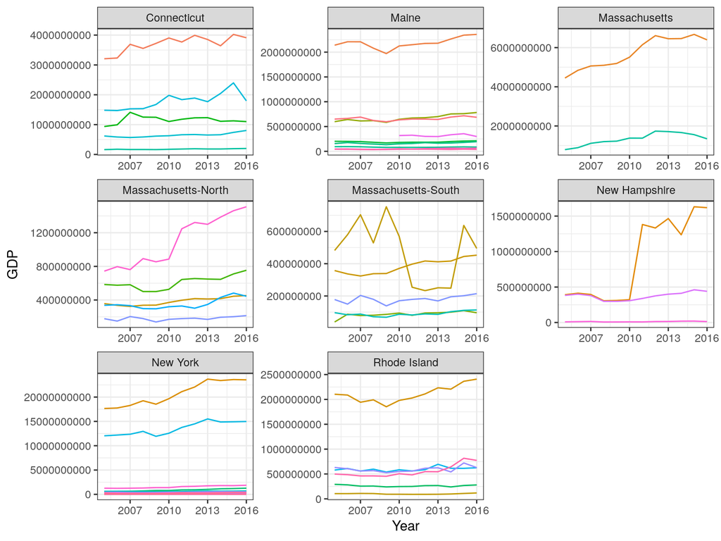

```r
ggplot(noep_data, aes(x = Year, y = GDP, color = County)) +
  geom_line() +
  theme_bw() +
  facet_wrap(~rgn_name, scales = "free") +
  theme(legend.position = "none")
```

## Meta-analysis

To identify some inconsistencies I see in the data, I’m going to take a look at the reported GDP at both the county level and statewide. One would expect that the sum of the county employment values would equal what is reported for the “Statewide” employment values. It seems that this is not the case.

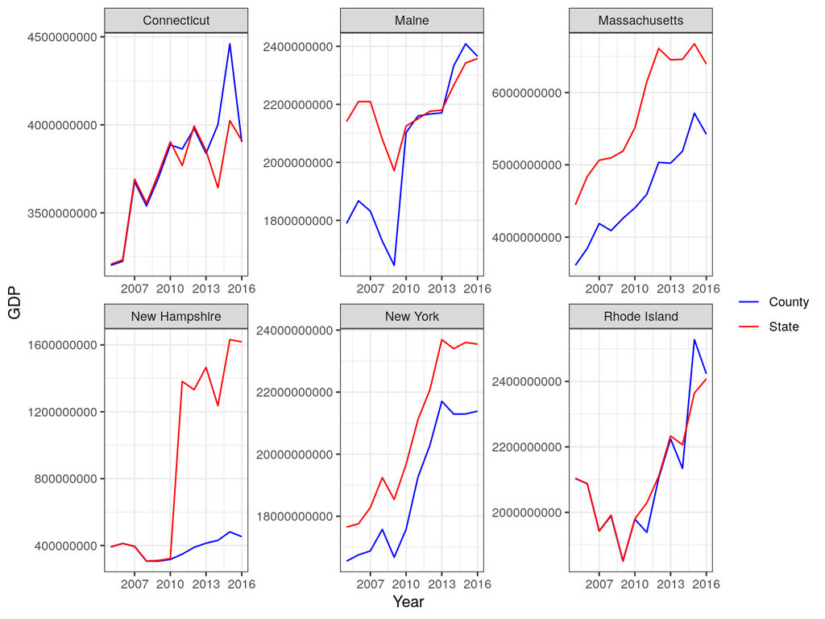

```r
states <-  c("Maine", "New Hampshire", "Rhode Island", "Massachusetts", "Connecticut", "New York")

meta <- function(state){

  all <- noep_data %>%
    filter(State == !!state,
           str_detect(County, "All")) %>%
    select(Year, GDP) %>%
    distinct() %>%
    rename(all_ctys_gdp = GDP)

  out <- noep_data %>%
    filter(State == !!state,
           str_detect(County, "All") == FALSE) %>%
    select(State, County, Year, GDP) %>%
    distinct() %>%
    group_by(Year) %>%
    summarize(totals = sum(GDP, na.rm = T)) %>%
    left_join(all) %>%
    rename(county_totals = totals,
           statewide = all_ctys_gdp) %>%
    gather(key = spatial_res, value = GDP, -Year) %>%
    mutate(State  = !!state)

  return(out)
}

t <- map_df(states, meta) %>%
  distinct()

ggplot(t, aes(x = Year, y = GDP, color = spatial_res)) +
  geom_line() +
  theme_bw() +
  facet_wrap(~State, scales = "free") +
  scale_color_manual(" ", labels = c("County", "State"), values = c("blue", "red"))
```